# STAT1003

Introduction to Data Science

Solution: Workshop 7

# Simple Linear Regression: Ames House Price Data

1. Load the file `sAmes.RData` into your R session. It contains the subsetted and then augmented Ames house price data we created in Workshop 6.

```r
print(load("sAmes.RData"))
```

```
[1] "sAmes"
```

2. First, let’s divide the dataset into to parts: a training set that we’re going to use to construct the model, and a test set that we’ll use to check how well the model fits. Set aside about 20% of the data for the test set.

```r
Index <- sample(nrow(sAmes), size = 0.8 * nrow(sAmes), replace = FALSE)
head(Index)
```

```
[1] 1023 1601  232   57  602 1424
```

```r
sAmes.train <- sAmes[Index, ]
sAmes.test <- sAmes[-Index, ]
```

3. Plot the two variables using the training set only.

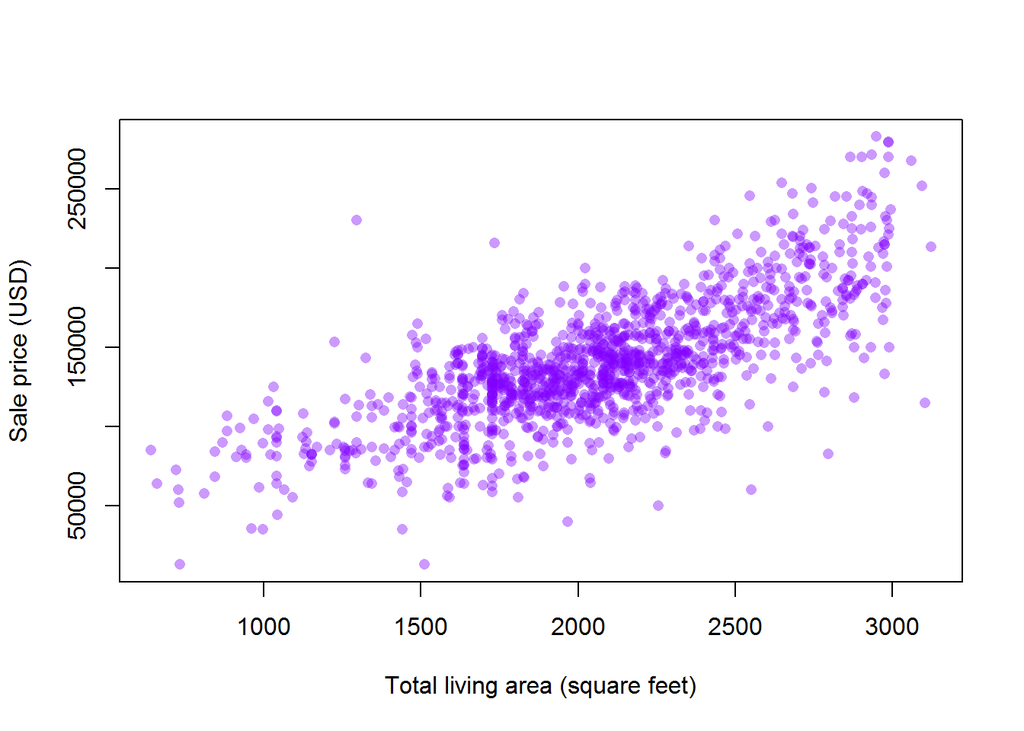

```r
plot(SalePrice ~ Total.Liv.Area, data = sAmes.train, xlab = "Total living area (square feet)",
    ylab = "Sale price (USD)", col = rgb(0.5, 0, 1, alpha = 0.4), pch = 16)
```

4. Construct a linear model relating `SalePrice` to `Total.Liv.Area`. Output a summary. Replot the data and then plot the least squares line of best fit. Comment.

```r
Model.lm <- lm(SalePrice ~ Total.Liv.Area, data = sAmes.train)
summary(Model.lm)
```

```
Call:
lm(formula = SalePrice ~ Total.Liv.Area, data = sAmes.train)

Residuals:
    Min      1Q  Median      3Q     Max
-110618  -15522    -931   16742  138705

Coefficients:
               Estimate Std. Error t value Pr(>|t|)
(Intercept)    9574.772   3469.073    2.76  0.00586 **
Total.Liv.Area   63.105      1.642   38.44  < 2e-16 ***
---
Signif. codes:  0 '***' 0.001 '**' 0.01 '*' 0.05 '.' 0.1 ' ' 1

Residual standard error: 26660 on 1291 degrees of freedom
  (1 observation deleted due to missingness)
Multiple R-squared:  0.5337,    Adjusted R-squared:  0.5334
F-statistic:  1478 on 1 and 1291 DF,  p-value: < 2.2e-16
```

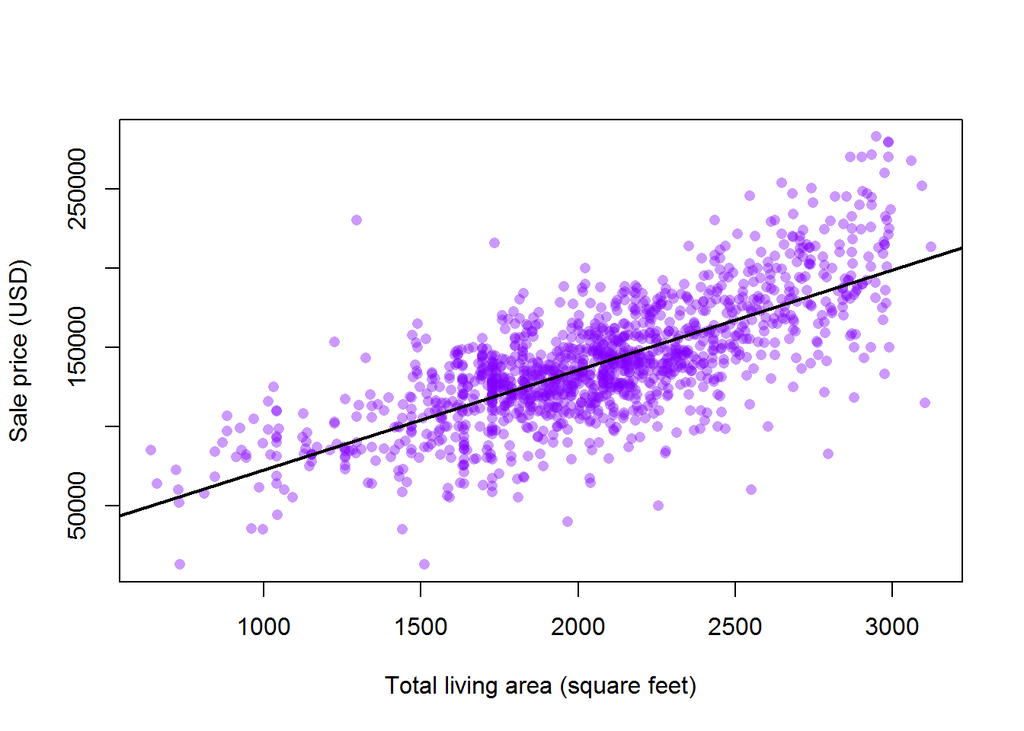

```r
plot(SalePrice ~ Total.Liv.Area, data = sAmes.train, xlab = "Total living area (square feet)",
    ylab = "Sale price (USD)", col = rgb(0.5, 0, 1, alpha = 0.4), pch = 16)
abline(Model.lm, lwd = 2)
```

5. Produce diagnostic plots, and evaluate them.

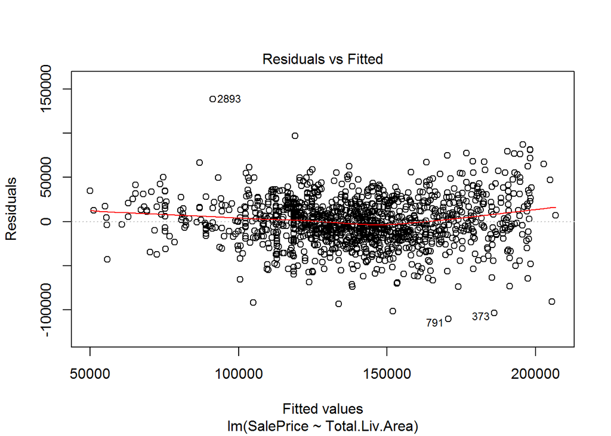

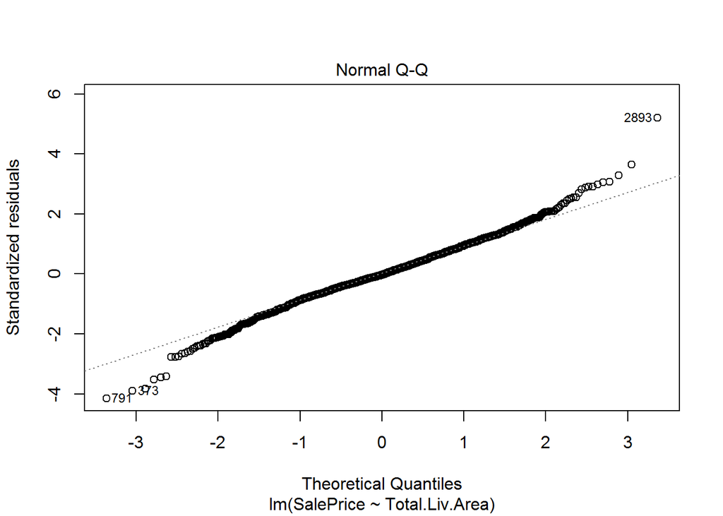

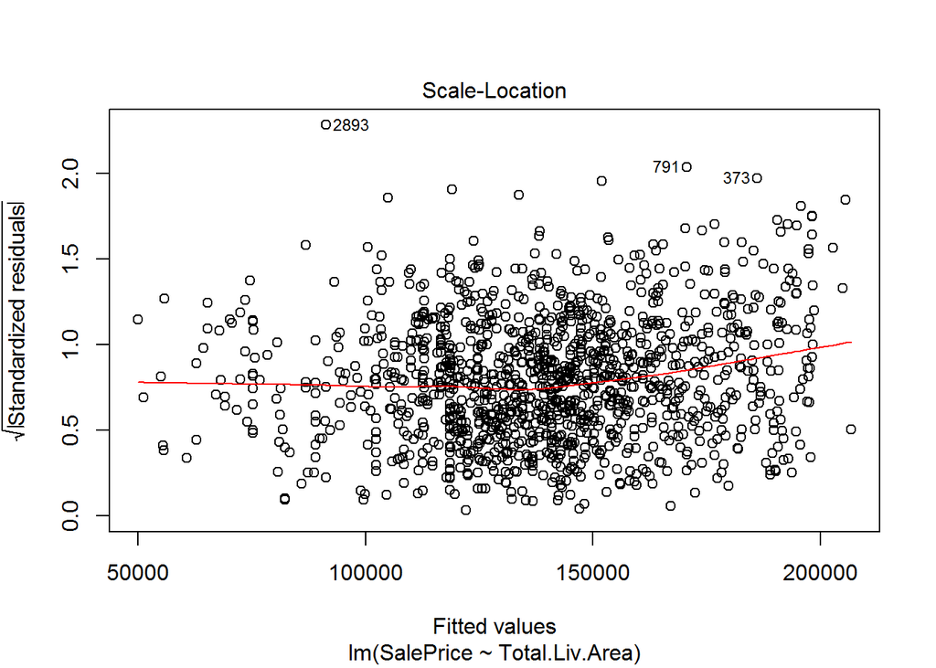

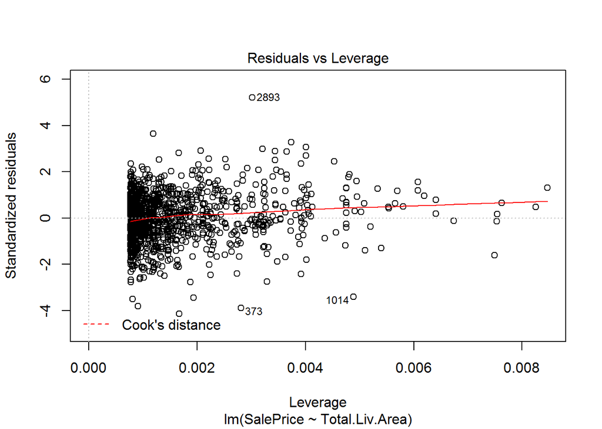

```r
plot(Model.lm)
```

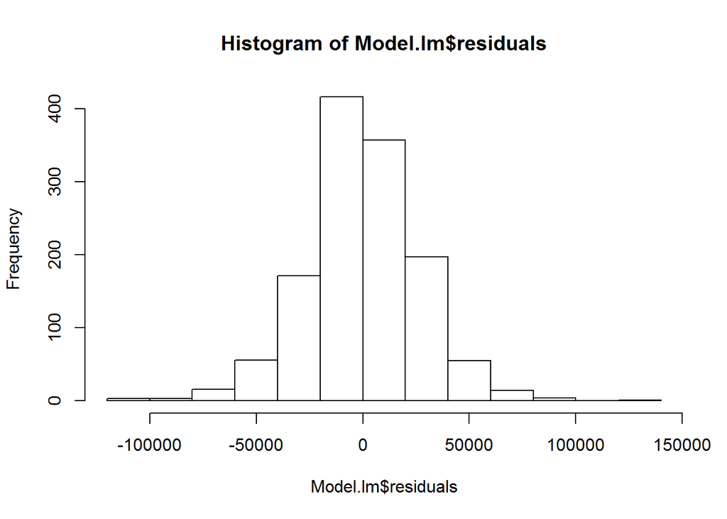

```r
hist(Model.lm$residuals)
```

6. Predict the sale prices of the houses in the test set. What plot could you construct that will give you a visual illustration of how well your model did?

```r
SalePrice.predict <- predict(Model.lm, newdata = sAmes.test)
head(SalePrice.predict)
```

```
       7       12       22       25       29       31
178442.9 158186.3 150045.8 145628.5 182607.8 111615.1
```

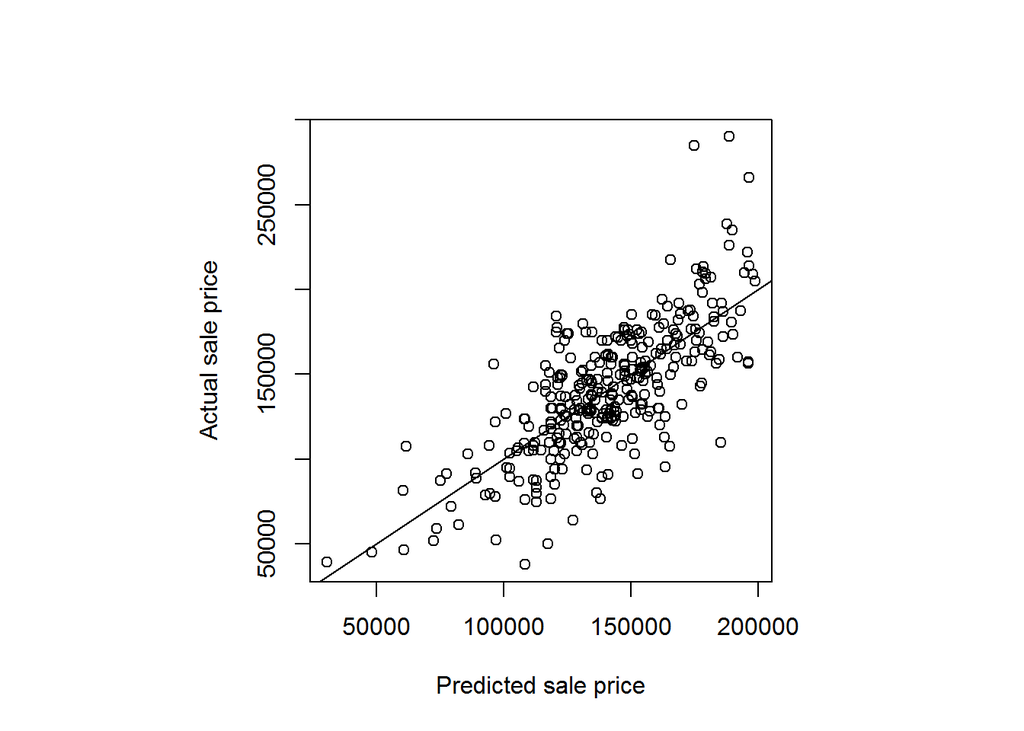

```r
par(pty = "s")
plot(SalePrice.predict, sAmes.test$SalePrice, xlab = "Predicted sale price",
    ylab = "Actual sale price")
abline(0, 1)
```

```r
# Calculate RMSEP

RMSEP <- sqrt(sum((SalePrice.predict - sAmes.test$SalePrice)^2)/length(SalePrice.predict))
RMSEP
```

```
[1] 25832.02
```

# Multiple Linear Regression: Sales Data Set

This is the data set that we will explore during the lecture. It is not as large as the Ames data set, but we’re going to use it to construct a simple multiple linear regression model for predicting `Sales`.

1. Using an appropriate command, read in the file `Advertising.csv`.

```r
Ad <- read.csv("Advertising.csv")
```

2. What is it’s structure, and how many variables and observations does it have?

```r
str(Ad)
```

```
'data.frame':   200 obs. of  4 variables:
 $ TV       : num  230.1 44.5 17.2 151.5 180.8 ...
 $ Radio    : num  37.8 39.3 45.9 41.3 10.8 48.9 32.8 19.6 2.1 2.6 ...
 $ Newspaper: num  69.2 45.1 69.3 58.5 58.4 75 23.5 11.6 1 21.2 ...
 $ Sales    : num  22.1 10.4 9.3 18.5 12.9 7.2 11.8 13.2 4.8 10.6 ...
```

All the variables are quantitative variables; there are no categorical ones.

3. Produce a scatterplot matrix using the function `pairs`. See the help file for a slightly fancier plot that will put histograms of the variables in the diagonal and the value of the correlation coefficient in the upper triangle.

See the chunk options I have used to get a slightly bigger plot than the default, and one that is square. These chunk options are **not** *R* code, so they do not go inside the chunk, where you would normally put *R* code.

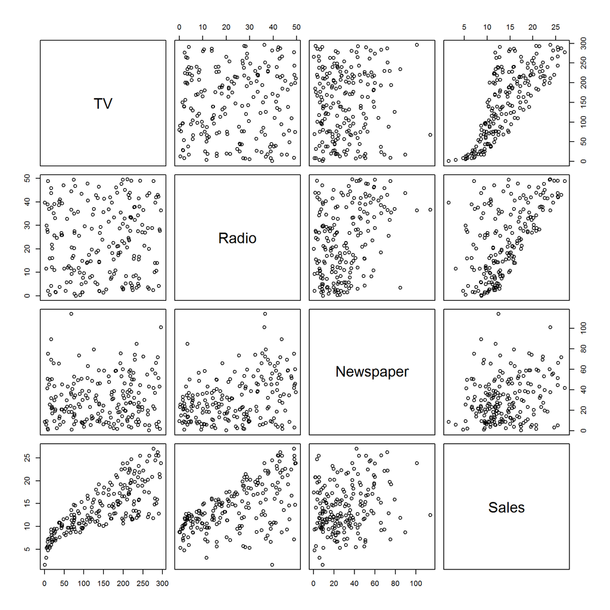

```r
plot(Ad)
```

4. Using the commands above, split the data set into a training set and a test set. Set about 15% aside.

```r
Index <- sample(nrow(Ad), floor(0.15 * nrow(Ad)))
TrainAd <- Ad[-Index, ]
TestAd <- Ad[Index, ]
```

If you’re not sure if you’ve done this correctly, you should check the number of rows in the test/training sets and make sure they add up to the number of rows in the original data set.

5. Using the training data only, construct a model for predicting `Sales` that contains only `TV`.

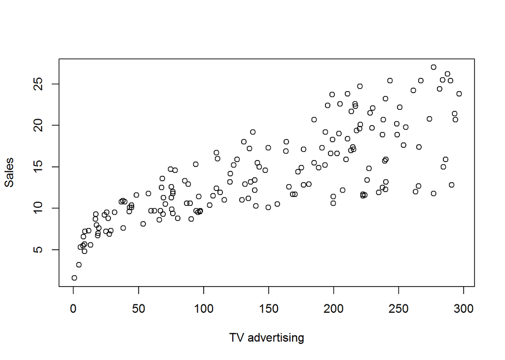

```r
plot(Sales ~ TV, data = TrainAd, xlab = "TV advertising", ylab = "Sales")
```

Always plot the data!

```r
TV.lm <- lm(Sales ~ TV, data = TrainAd)
```

```r
summary(TV.lm)
```

```
Call:
lm(formula = Sales ~ TV, data = TrainAd)

Residuals:
    Min      1Q  Median      3Q     Max
-8.6365 -1.8510 -0.1093  2.0142  7.0319

Coefficients:
            Estimate Std. Error t value Pr(>|t|)
(Intercept) 7.034109   0.495166   14.21   <2e-16 ***
TV          0.048436   0.002917   16.61   <2e-16 ***
---
Signif. codes:  0 '***' 0.001 '**' 0.01 '*' 0.05 '.' 0.1 ' ' 1

Residual standard error: 3.296 on 168 degrees of freedom
Multiple R-squared:  0.6215,    Adjusted R-squared:  0.6192
F-statistic: 275.8 on 1 and 168 DF,  p-value: < 2.2e-16
```

Make sure that you know how to interpret the summary above. If not, see the lecture notes.

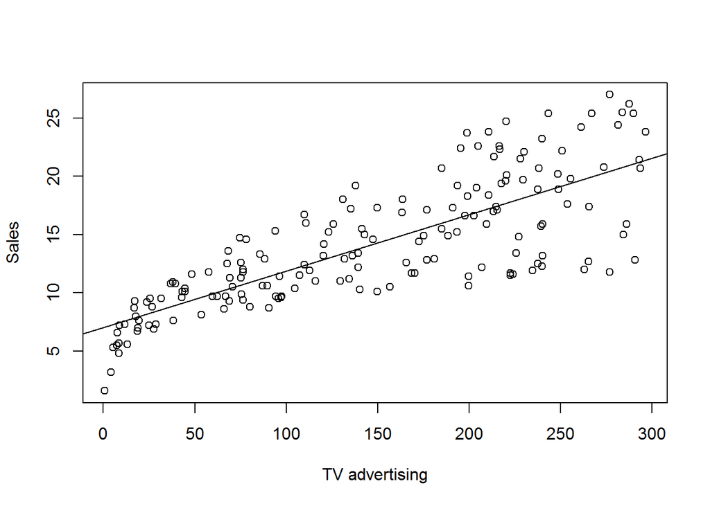

```r
plot(Sales ~ TV, data = TrainAd, xlab = "TV advertising", ylab = "Sales")
abline(TV.lm)
```

The function `abline` is used to plot the fitted line onto a plot of the data.

6. Construct some diagnostic plots - you will clearly see that some of the assumptions of least squares regression have been violated.

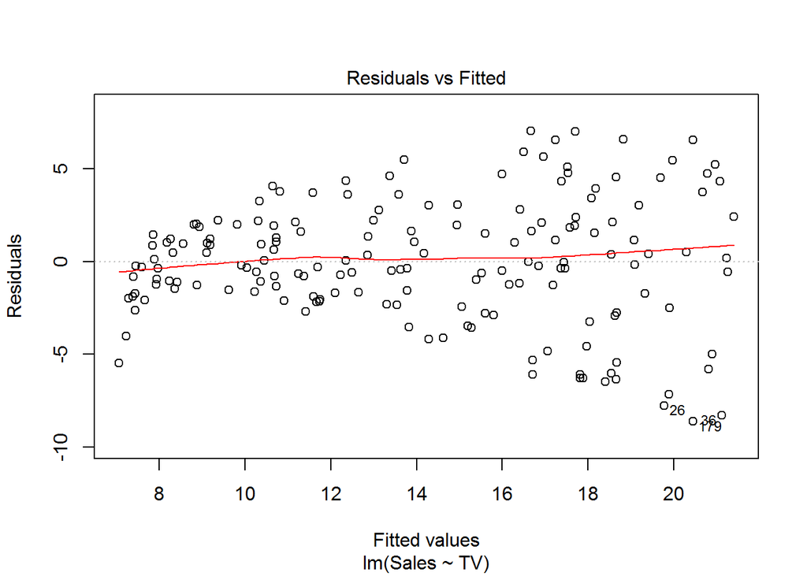

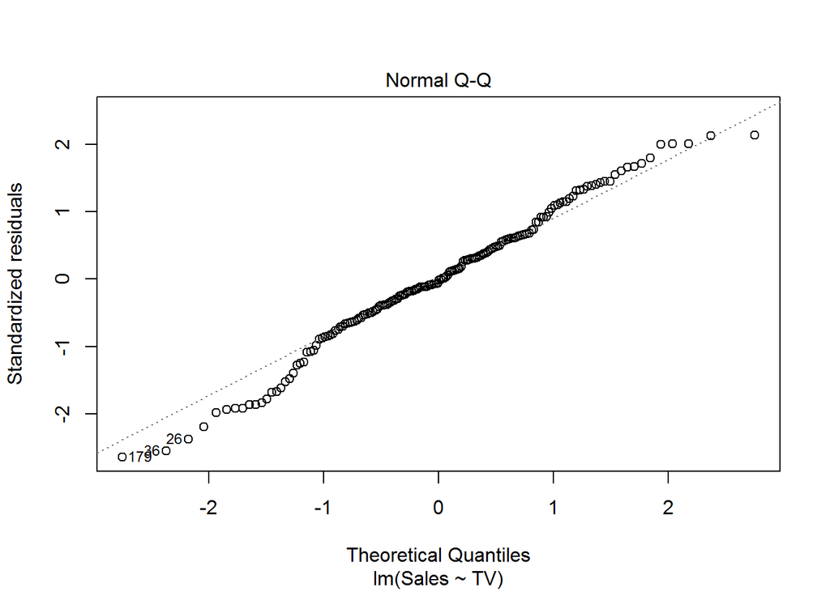

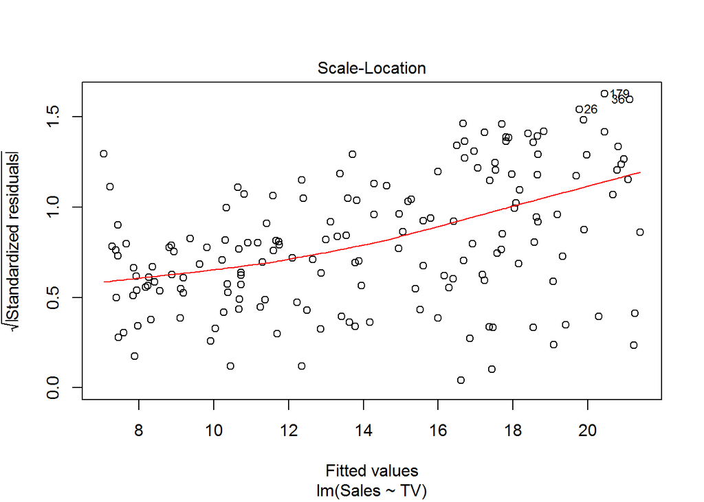

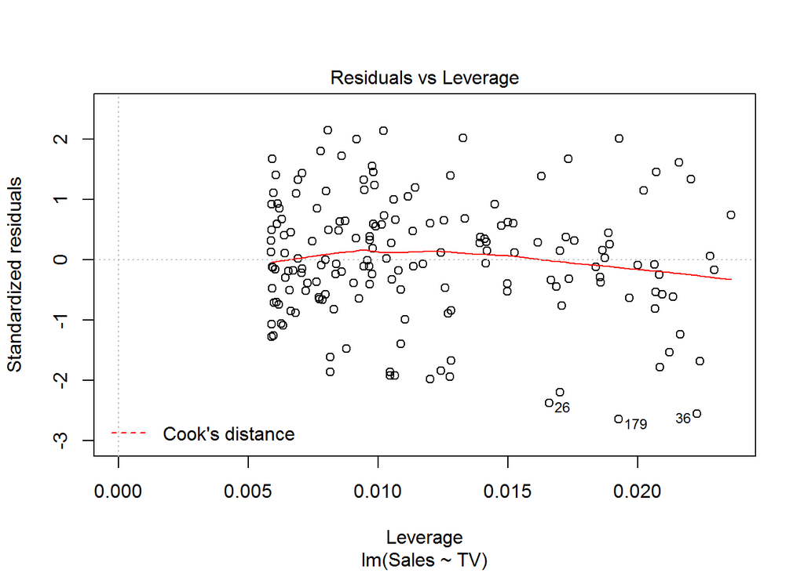

```r
plot(TV.lm)
```

For now, we’re only interested in the first three plots: if there’s no curvature in the first plot (and there doesn’t appear to be), the linear relationship between `Sales` and `TV` is appropriate (though we can see the nonconstant spread that we’ll also see in plot 3); in the second, we’re assessing whether the residuals are *approximately* Normally distributed (which they more or less are); in the third plot, *R* has helpfully drawn a smooth curve to the points, and it shows an upward trend, which indicates nonconstant variance. So, clearly, that assumption has been violated. There are methods to carry out least squares estimation in this situation, but we will not consider those in this unit.

7. Predict `Sales` in the test set, and then calculate the root mean square error of prediction.

```r
Sales.pred <- predict(TV.lm, newdata = TestAd)
```

```r
RMSEP <- sqrt(sum((TestAd$Sales - Sales.pred)^2)/length(Sales.pred))
RMSEP
```

```
[1] 3.068184
```

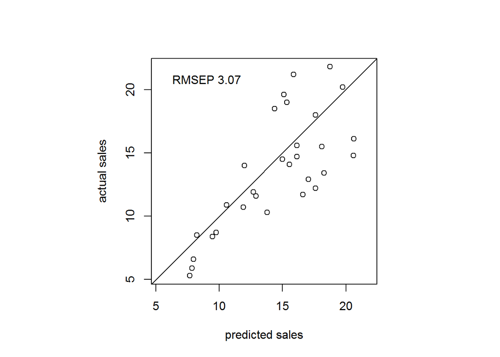

```r
par(pty = "s")
Range <- range(c(TestAd$Sales, Sales.pred))
plot(TestAd$Sales ~ Sales.pred, xlab = "predicted sales", ylab = "actual sales",
    xlim = Range, ylim = Range)
abline(0, 1)
text(min(Range) + 1, max(Range) - 1, paste("RMSEP", round(RMSEP, 2)), adj = 0)
```

Notice that in the plot above, the scales have been forced to be identical; furthermore, the graphical parameter `par(pty = "s")` has been used to ensure that the plot is square. Finally, to make the plot more informative, the value of the RMSEP has been added using the `text` command.

8. Carry out steps 5. - 7., but this time, fit a model that contains `TV`, `Radio`, and their interaction (`TV:Radio`).

In brief:

```r
TV_Radio.lm <- lm(Sales ~ TV + Radio + TV:Radio, data = TrainAd)
summary(TV_Radio.lm)
```

```
Call:
lm(formula = Sales ~ TV + Radio + TV:Radio, data = TrainAd)

Residuals:
    Min      1Q  Median      3Q     Max
-6.2597 -0.3713  0.1702  0.5935  1.5798

Coefficients:
             Estimate Std. Error t value Pr(>|t|)
(Intercept) 6.894e+00  2.875e-01   23.98   <2e-16 ***
TV          1.835e-02  1.739e-03   10.55   <2e-16 ***
Radio       2.329e-02  9.869e-03    2.36   0.0194 *
TV:Radio    1.112e-03  5.805e-05   19.16   <2e-16 ***
---
Signif. codes:  0 '***' 0.001 '**' 0.01 '*' 0.05 '.' 0.1 ' ' 1

Residual standard error: 0.9759 on 166 degrees of freedom
Multiple R-squared:  0.9672,    Adjusted R-squared:  0.9666
F-statistic:  1632 on 3 and 166 DF,  p-value: < 2.2e-16
```

All the coefficients are significantly different from zero. The value of $R^2$ has increased, though this will always be the case when additional variables have been added. A better measure (though not infallible) is adjusted-$R^2$, which adjusts for the number of variables in the models, and this too has increased considerably.

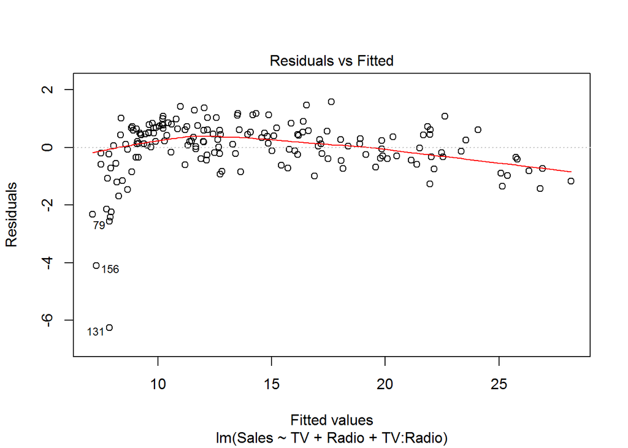

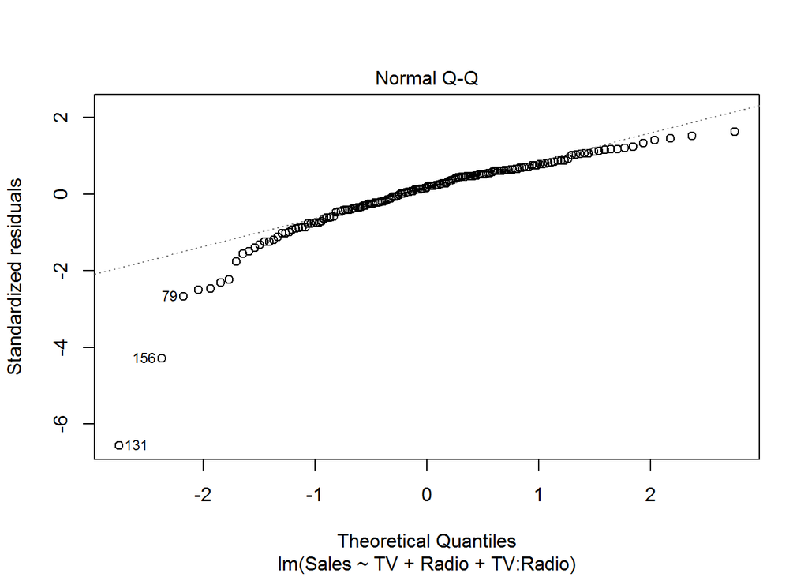

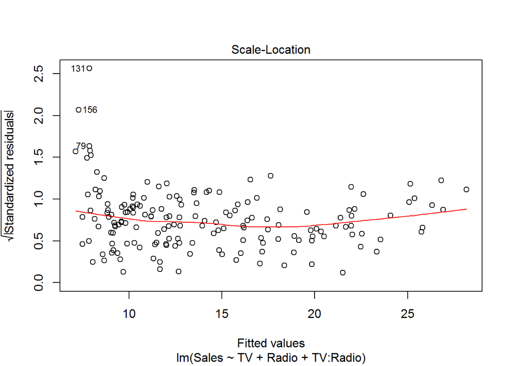

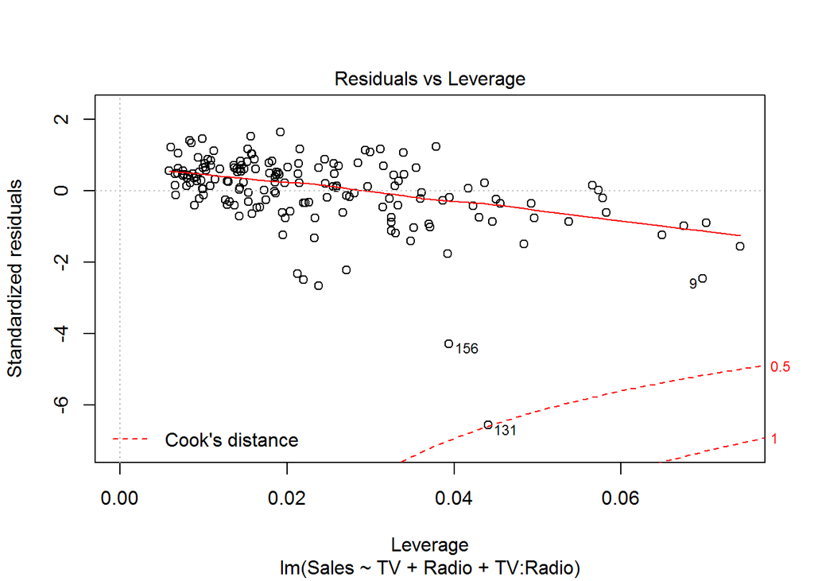

```r
plot(TV_Radio.lm)
```

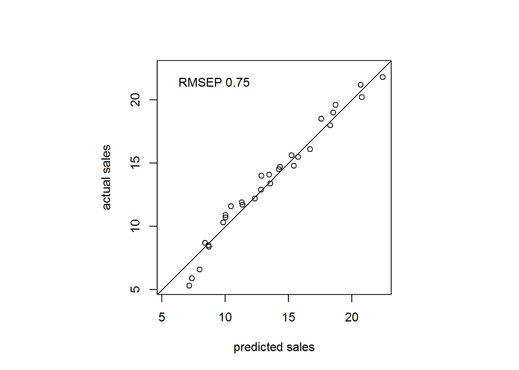

```r
Sales2.pred <- predict(TV_Radio.lm, newdata = TestAd)
RMSEP <- sqrt(sum((TestAd$Sales - Sales2.pred)^2)/length(Sales2.pred))
par(pty = "s")
Range <- range(c(TestAd$Sales, Sales2.pred))
plot(TestAd$Sales ~ Sales2.pred, xlab = "predicted sales", ylab = "actual sales",
    xlim = Range, ylim = Range)
abline(0, 1)
text(min(Range) + 1, max(Range) - 1, paste("RMSEP", round(RMSEP, 2)), adj = 0)
```

9. Which model has a smaller root mean square error of prediction?

Clearly, including `Radio` and its interaction with `TV` results in a model that yields more precise and accurate predictions!.